# Quality Control

EUT046 - Version 2

Imke Bruns (0000-0001-9681-6693)

2025-05-23

# 1 Set up analysis

## 1.1 Load packages

### 1.1.1 CRAN

Install and load CRAN packages.

```r
# if(!require(pacman, quietly = TRUE)){ install.packages('pacman') }

pacman::p_load(tidyverse, data.table, ggfortify, here)
```

### 1.1.2 BioManager

Install and load Bioconductor packages.

```r
# if (!require('BiocManager', quietly = TRUE)){ install.packages('BiocManager')
# } if (!require(DESeq2, quietly = TRUE)){ BiocManager::install('DESeq2') }

library(DESeq2)
```

## 1.2 Load functions

Load manual functions we need in the script.

```r
source(file.path(here(), "functions.R"), local = knitr::knit_global())
```

## 1.3 Set color scheme

Set standard color scheme for plots.

```r
# color list for plotting
color25 <- c(
  "dodgerblue2", "#E31A1C", # red
  "green4",
  "#6A3D9A", # purple
  "#FF7F00", # orange
  "black", "gold1",
  "skyblue2", "#FB9A99", # lt pink
  "palegreen2",
  "#CAB2D6", # lt purple
  "#FDBF6F", # lt orange
  "gray70", "khaki2",
  "maroon", "orchid1", "deeppink1", "blue1", "steelblue4",
  "darkturquoise", "green1", "yellow4", "yellow3",
  "darkorange4", "brown", "forestgreen"
)
```

## 1.4 Set directories

Set directories.

```r
# data directory
if (!dir.exists(paste0("data/"))) {
    dir.create(path = file.path(here(), "data"))
}
dataDir <- file.path(here(), "data", studyNR)

# input directory
if (!dir.exists(paste0("input/", studyNR, "/"))) {
    dir.create(path = file.path(here(), "input", studyNR))
}
inputDir <- file.path(here(), "input", studyNR)

# output directory
if (!dir.exists(paste0("output/", studyNR, "/"))) {
    dir.create(path = file.path(here(), "output", studyNR))
}
```

```r
outputDir <- file.path(here(), "output", studyNR)

# plot directory
if (!dir.exists(paste0("figures/", studyNR, "/"))) {
    dir.create(path = file.path(here(), "figures", studyNR))
}
plotDir <- file.path(here(), "figures", studyNR)
```

## 1.5 Thresholds for library size

Here, we set the threshold for the library size filter. We set this to be 20% of the expected read depth which is in this case 3 000 000.

```r
expectedReadDepth = 3e+06
libSizeFilter = 0.2 * expectedReadDepth
```

## 1.6 Import data

Import needed data files.

```r
# raw counts
rawcounts = read.csv(file.path(inputDir, paste0(studyNR, "_counts_per_gene_per_sample.csv"))) %>%
    dplyr::rename(probe_id = Column1)


# metadata
metadata = read.csv(file.path(inputDir, paste0(studyNR, "_metadata.csv"))) %>%
    mutate(TREATMENT_ID = gsub(" ", "", TREATMENT_ID), MEAN_ID = if_else(COMPOUND %in%
        c("DMEM", "DMSO", "NaCl"), true = TREATMENT_ID, false = paste0(TREATMENT_ID,
        "_R", REPLICATE))) %>%
    mutate(CONCENTRATION = factor(CONCENTRATION, levels = c("0uM", "0.1uM", "0.5uM",
        "1uM", "2.5uM", "5uM", "10uM", "20uM", "30uM", "50uM")), TIMEPOINT = factor(TIMEPOINT,
        levels = c("0hr", "4hr", "8hr", "16hr", "24hr", "48hr", "72hr")), DOSE = as.numeric(gsub("uM",
        "", CONCENTRATION)))

# manifest
manifest = read.delim(file.path(dirname(dataDir), "Manifests", "Temposeq_manifest_Human_WT_1.2_realignment_96percent_2023-05-15.txt"))
```

# 2 Quality control

## 2.1 Probe QC

We start with the quality control for the probes.

### 2.1.1 STEP 1: Probe alignment

Here, we align the probes with the manifest.

```r
rawcounts_entrezid = rawcounts %>%
    left_join(manifest %>%
        select(Probe_ID, gene_symbol_entrez_id), by = c(probe_id = "Probe_ID")) %>%
    select(probe_id, gene_symbol_entrez_id, everything())
```

### 2.1.2 STEP 2: Relevance filter

Apply relevance filter adapted from the R-ODAF pipeline (see: https://doi.org/10.1016/j.yrtph.2022.105143)

```r
relevance_summary = relevance_filter(countdata = apply(rawcounts_entrezid %>%
    column_to_rownames("probe_id") %>%
    select(-gene_symbol_entrez_id), 2, cpm_normalization) %>%
    as.data.frame(), metadata = metadata)
rawcounts_entrezid_relevanceFilter = rawcounts_entrezid %>%
    filter(probe_id %in% (relevance_summary %>%
        filter(keep == TRUE) %>%
        pull(probe_id)))
# %>% select(-probe_id)


cat("The relevance filter removed", nrow(rawcounts_entrezid) - nrow(rawcounts_entrezid_relevanceFilter),
    "probes.", nrow(rawcounts_entrezid_relevanceFilter), "are left for further analysis.")
```

```
## The relevance filter removed 8477 probes. 12634 are left for further analysis.
```

### 2.1.3 STEP 3: Spurious spikes

Group replicate groups + probe_id, calculate the ratio between the maximum of probeX and the sum of probeX for each replicate group. If this ratio exceeds 1.4*number of replicates^-0.66, flag. The flagged genes are in the `spike_summary` table.

```r
log2cpmcounts_entrezid_relevanceFilter_long = log2(apply(rawcounts_entrezid_relevanceFilter %>%
    column_to_rownames("probe_id") %>%
    select(-gene_symbol_entrez_id), 2, cpm_normalization) + 1) %>%
    as.data.frame() %>%
    rownames_to_column("probe_id") %>%
    mutate(gene_symbol_entrez_id = rawcounts_entrezid_relevanceFilter$gene_symbol_entrez_id) %>%
    pivot_longer(-c(gene_symbol_entrez_id, probe_id), names_to = "SAMPLE_ID", values_to = "log2cpm") %>%
    left_join(metadata %>%
        select(SAMPLE_ID, TREATMENT_ID), by = "SAMPLE_ID")



# calculate spike ratios and thresholds per gene group
spike_check = log2cpmcounts_entrezid_relevanceFilter_long %>%
    group_by(probe_id, TREATMENT_ID) %>%
    summarize(max_count = max(log2cpm), sum_count = sum(log2cpm), n_samples = n(),
        ratio = if_else(sum_count == 0, true = 0, false = max_count/sum_count), threshold = 1.4 *
            (n_samples^-0.66), spike = ratio >= threshold, .groups = "drop")


# count how many groups have spikes per gene
spike_summary = spike_check %>%
    group_by(probe_id) %>%
    summarize(groups_with_spikes = sum(spike), pass_spike_filter = groups_with_spikes <=
        1, .groups = "drop")

head(spike_summary)
```

| probe_id | groups_with_spikes | pass_spike_filter |
| --- | --- | --- |
| A2M_12371 | 14 | FALSE |
| A4GALT_12912 | 0 | TRUE |
| AAAS_23947 | 0 | TRUE |
| AACS_17112 | 0 | TRUE |
| AAED1_15590 | 0 | TRUE |
| AAGAB_23638 | 0 | TRUE |

```r
table(spike_summary$pass_spike_filter)
```

```
##
## FALSE  TRUE
##  2947  9687
```

```r
spike_flag = spike_summary %>%
    filter(pass_spike_filter == FALSE) %>%
    left_join(log2cpmcounts_entrezid_relevanceFilter_long %>%
        select(probe_id, gene_symbol_entrez_id), by = "probe_id") %>%
    pull(gene_symbol_entrez_id) %>%
    unique()

cat("The spurious spike filter flagged", length(spike_flag), "genes.")
```

```
## The spurious spike filter flagged 2804 genes.
```

### 2.1.4 STEP 4: Sum probes

We sum the probes targeting the same gene.

```r
# count isomeric probes
cat("Before sum counts isomeric probes, there are", length(rawcounts_entrezid_relevanceFilter$gene_symbol_entrez_id %>%
    duplicated() %>%
    which()), "duplicated gene symbols \n")
```

```
## Before sum counts isomeric probes, there are 1101 duplicated gene symbols
```

```r
rawcounts_entrezid_relevanceFilter_sumProbes = aggregate(rawcounts_entrezid_relevanceFilter %>%
    select(where(is.numeric)), by = list(gene_symbol_entrez_id = rawcounts_entrezid_relevanceFilter$gene_symbol_entrez_id),
    FUN = sum)

cat("After all probe QC steps, there are", nrow(rawcounts_entrezid_relevanceFilter_sumProbes),
    "unique genes left")
```

```
## After all probe QC steps, there are 11532 unique genes left
```

### 2.1.5 Probe QC output

Generate output files after the probe QC.

```r
# cpm counts
cpmcounts_entrezid_relevancefilter_sumProbes = apply(rawcounts_entrezid_relevanceFilter_sumProbes %>%
    column_to_rownames("gene_symbol_entrez_id"), 2, cpm_normalization) %>%
    as.data.frame() %>%
    rownames_to_column("gene_symbol_entrez_id")

# log2cpm counts
log2cpmcounts_entrezid_relevanceFilter_sumProbes = log2(cpmcounts_entrezid_relevancefilter_sumProbes %>%
    column_to_rownames("gene_symbol_entrez_id") + 1) %>%
    rownames_to_column("gene_symbol_entrez_id")
```

### 2.1.6 Visualize in PCA

Show low QC genes in PCA scale

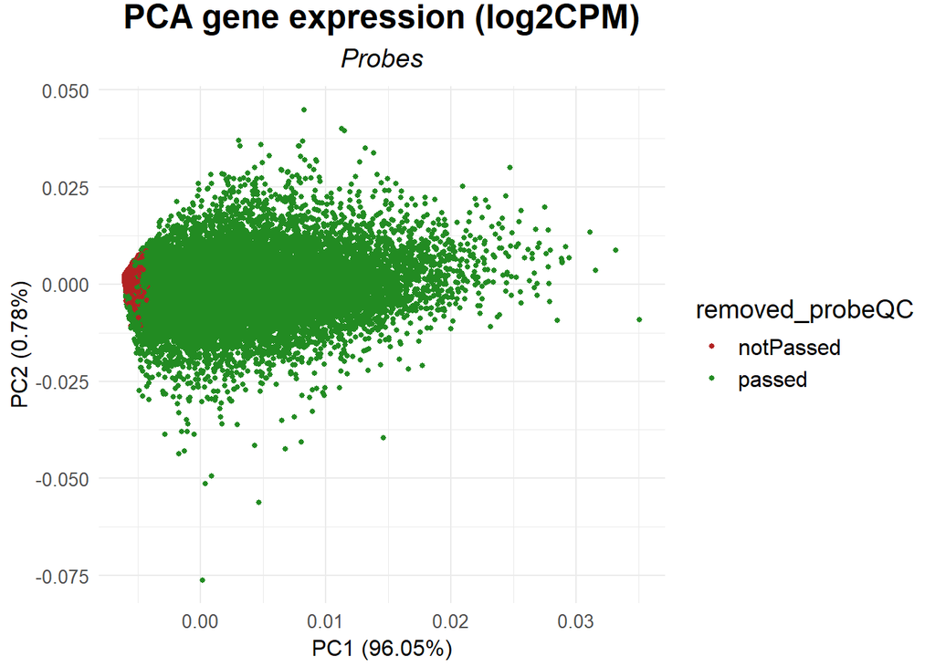

```r
pcaData_beforeProbeFilter = log2(apply(rawcounts %>%
    column_to_rownames("probe_id"), 2, cpm_normalization) + 1) %>%
    as.data.frame() %>%
    rownames_to_column("probe_id") %>%
    mutate(removed_probeQC = if_else(probe_id %in% (relevance_summary %>%
        filter(keep == TRUE) %>%
        pull(probe_id)), true = "passed", false = "notPassed"), flagged_probeQC = if_else(probe_id %in%
        (spike_summary %>%
            filter(pass_spike_filter == TRUE) %>%
            pull(probe_id)), true = "passed", false = "spike_flagged"))


pcaOutput_beforeProbeFilter = prcomp(pcaData_beforeProbeFilter %>%
    select(where(is.numeric)))

autoplot(pcaOutput_beforeProbeFilter, data = pcaData_beforeProbeFilter, color = "removed_probeQC",
    size = 1) + labs(title = "PCA gene expression (log2CPM)", subtitle = "Probes") +
    scale_color_manual(values = c("firebrick", "forestgreen"), breaks = c("notPassed",
        "passed"))
```

Show flagged genes in PCA scale

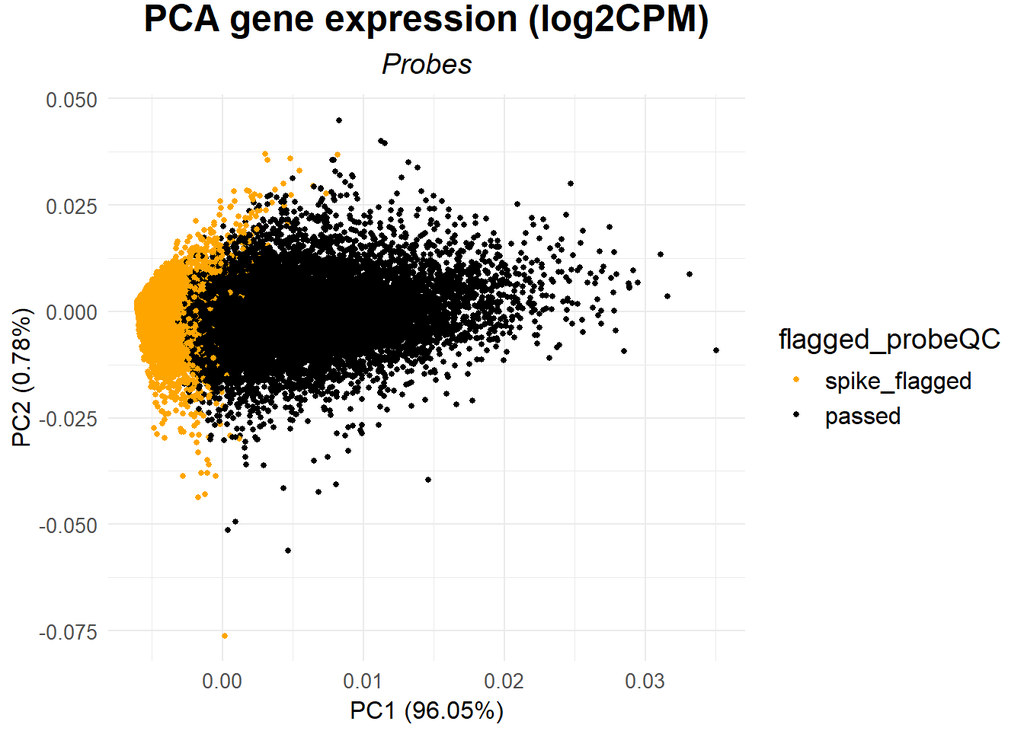

```r
autoplot(pcaOutput_beforeProbeFilter, data = pcaData_beforeProbeFilter, color = "flagged_probeQC",
    size = 1) + labs(title = "PCA gene expression (log2CPM)", subtitle = "Probes") +
    scale_color_manual(values = c("orange", "black"), breaks = c("spike_flagged",
        "passed"))
```

### 2.1.7 Save output

```r
save(
  # metadata
  metadata,
  # raw counts
  rawcounts_entrezid_relevanceFilter_sumProbes,
  # cpm counts
  cpmcounts_entrezid_relevancefilter_sumProbes,
  # log2cpm counts
  log2cpmcounts_entrezid_relevanceFilter_sumProbes,

  file = file.path(outputDir, "updatedVersion", paste0(studyNR, "_dataAfterProbeQC.RData"))
)
```

## 2.2 Sample QC

Now we perform the quality control for the samples.

### 2.2.1 STEP 5: Library size filter (NMR)

Remove samples if library size is < 20% of the intended read depth. The filter has been set on the top of the script.

#### 2.2.1.1 Add library size to metadata

```r
metadata %>%
    mutate(LIBRARY_SIZE = colSums(rawcounts_entrezid_relevanceFilter_sumProbes %>%
        select(where(is.numeric))), LIBRARY_SIZE_PURE = colSums(rawcounts %>%
        select(where(is.numeric)))) -> metadata
```

#### 2.2.1.2 Plot library size

Also compare pure library size obtained form raw counts with library size after probe QC

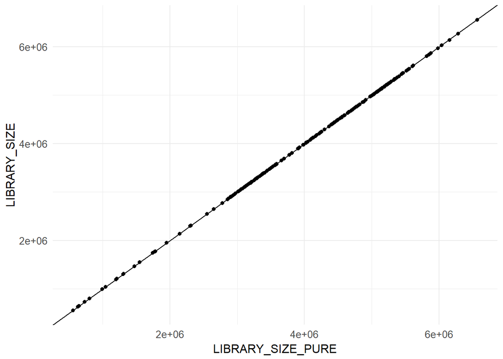

```r
# compare pure library size (from raw counts) with library size after probe QC
p1 = ggplot(metadata, aes(x = LIBRARY_SIZE_PURE, y = LIBRARY_SIZE)) + geom_point() +
    geom_abline()

p1
```

```r
# show differences in table
metadata %>%
    select(LIBRARY_SIZE, LIBRARY_SIZE_PURE) %>%
    head(10)
```

|  | LIBRARY_SIZE | LIBRARY_SIZE_PURE |
| --- | --- | --- |
| 1 | 4584447 | 4595162 |
| 2 | 4737945 | 4750036 |
| 3 | 4627275 | 4641319 |
| 4 | 5387085 | 5404366 |
| 5 | 5178142 | 5191120 |
| 6 | 4856378 | 4868083 |
| 7 | 4437823 | 4449172 |
| 8 | 5328935 | 5342400 |
| 9 | 4575955 | 4587873 |
| 10 | 5205930 | 5218649 |

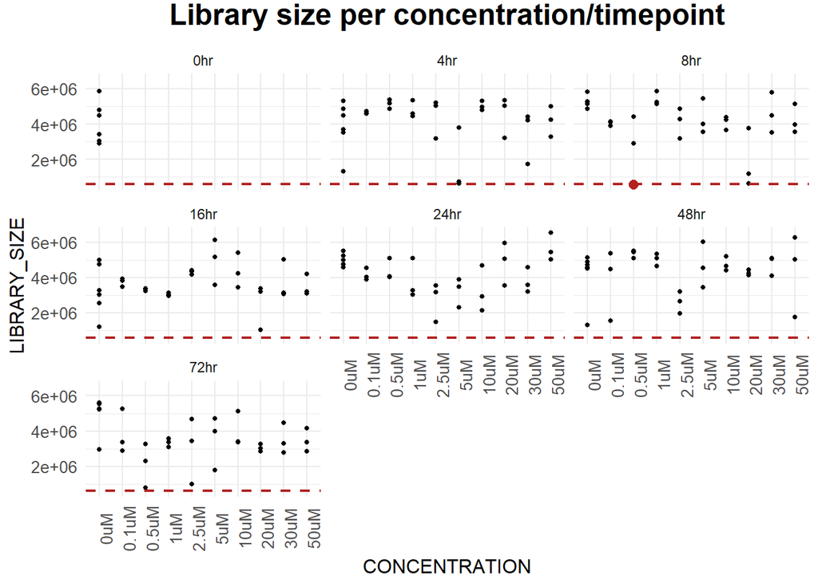

```r
# plot library size per concentration/timepoint
p2 = ggplot(metadata, aes(x = CONCENTRATION, y = LIBRARY_SIZE, color = LIBRARY_SIZE >
    libSizeFilter, size = LIBRARY_SIZE > libSizeFilter)) + geom_point() + facet_wrap(~TIMEPOINT) +
    geom_hline(yintercept = libSizeFilter, lty = 2, color = "firebrick", linewidth = 0.8) +
    scale_color_manual(values = c("firebrick", "black"), breaks = c(FALSE, TRUE)) +
    scale_size_manual(values = c(1, 2.5), breaks = c(TRUE, FALSE)) + theme(legend.position = "none",
    axis.text.x = element_text(angle = 90)) + labs(title = "Library size per concentration/timepoint")

p2
```

#### 2.2.1.3 Remove samples

From metadata

```r
cat("We filter all samples with a library size of <", libSizeFilter, "\n")
```

```
## We filter all samples with a library size of < 6e+05
```

```r
metadata_libSize = metadata %>%
    filter(LIBRARY_SIZE >= libSizeFilter)

cat("The following samples have been removed due to low library size:\n", paste(metadata %>%
    filter(LIBRARY_SIZE < libSizeFilter) %>%
    pull(SAMPLE_ID), collapse = ", "))
```

```
## The following samples have been removed due to low library size:
##  S_8h_Cis8_Rep1
```

From counts

```r
# raw counts
rawcounts_entrezid_relevanceFilter_sumProbes_libSize = rawcounts_entrezid_relevanceFilter_sumProbes %>%
    select(gene_symbol_entrez_id, all_of(metadata_libSize$SAMPLE_ID))

# cpm counts
cpmcounts_entrezid_relevancefilter_sumProbes_libSize = cpmcounts_entrezid_relevancefilter_sumProbes %>%
    select(gene_symbol_entrez_id, all_of(metadata_libSize$SAMPLE_ID))

# log2cpm counts
log2cpmcounts_entrezid_relevanceFilter_sumProbes_libSize = log2cpmcounts_entrezid_relevanceFilter_sumProbes %>%
    select(gene_symbol_entrez_id, all_of(metadata_libSize$SAMPLE_ID))
```

### 2.2.2 STEP 6: Replicate correlation (rCOR)

We perform replicate correlation on the log2cpm counts, to minimize the effect of outliers.

#### 2.2.2.1 Pairwise

Calculate replicate correlation for each pair combination

```r
replicateFilterOutput <- data.frame()

for (i in unique(metadata_libSize$TREATMENT_ID)) {
    metaDataReps <- metadata_libSize %>%
        filter(TREATMENT_ID == i)

    if (nrow(metaDataReps) > 1) {
        log2cpmDataReps <- log2cpmcounts_entrezid_relevanceFilter_sumProbes_libSize[,
            metaDataReps$SAMPLE_ID]

        colnames(log2cpmDataReps)

        for (j in 1:ncol(log2cpmDataReps)) {
            for (k in 1:ncol(log2cpmDataReps)) {
                sample_A <- colnames(log2cpmDataReps)[j]
                sample_B <- colnames(log2cpmDataReps)[k]

                if (sample_A != sample_B) {

                  paste0("Looking at ", sample_A, " vs. ", sample_B)

                  r2 <- cor(log2cpmDataReps[, j], log2cpmDataReps[, k])

                  replicateFilterOutput <- rbind(replicateFilterOutput, data.frame(TREATMENT_ID = i,
                    sample_A = sample_A, sample_B = sample_B, comp = paste0(sample_A,
                      " v. ", sample_B), r2 = r2))
                }
            }
        }
    }
}

replicateFilterOutput <- replicateFilterOutput %>%
    arrange(TREATMENT_ID)

head(replicateFilterOutput)
```

|  | TREATMENT_ID | sample_A | sample_B | comp | r2 |
| --- | --- | --- | --- | --- | --- |
| 1 | RPTEC-TERT1_CSP_16hr_0.1uM | S_16h_Cis9_Rep1 | S_16h_Cis9_Rep2 | S_16h_Cis9_Rep1 v. S_16h_Cis9_Rep2 | 0.9145072 |
| 2 | RPTEC-TERT1_CSP_16hr_0.1uM | S_16h_Cis9_Rep1 | S_16h_Cis9_Rep3 | S_16h_Cis9_Rep1 v. S_16h_Cis9_Rep3 | 0.9041115 |
| 3 | RPTEC-TERT1_CSP_16hr_0.1uM | S_16h_Cis9_Rep2 | S_16h_Cis9_Rep1 | S_16h_Cis9_Rep2 v. S_16h_Cis9_Rep1 | 0.9145072 |
| 4 | RPTEC-TERT1_CSP_16hr_0.1uM | S_16h_Cis9_Rep2 | S_16h_Cis9_Rep3 | S_16h_Cis9_Rep2 v. S_16h_Cis9_Rep3 | 0.9758779 |
| 5 | RPTEC-TERT1_CSP_16hr_0.1uM | S_16h_Cis9_Rep3 | S_16h_Cis9_Rep1 | S_16h_Cis9_Rep3 v. S_16h_Cis9_Rep1 | 0.9041115 |
| 6 | RPTEC-TERT1_CSP_16hr_0.1uM | S_16h_Cis9_Rep3 | S_16h_Cis9_Rep2 | S_16h_Cis9_Rep3 v. S_16h_Cis9_Rep2 | 0.9758779 |

Calculate the highest replicate correlation for each sample

```r
replicateFilterOutput <- replicateFilterOutput %>%
    separate(TREATMENT_ID, into = c("cell_line", "compound", "time", "concentration"),
        sep = "_", remove = FALSE) %>%
    group_by(sample_A) %>%
    mutate(max_r2 = max(r2, na.rm = T), factor_conc = as.numeric(gsub("uM", "", concentration)),
        concentration = factor(concentration, levels = c("0uM", "0.1uM", "0.5uM",
            "1uM", "2.5uM", "5uM", "10uM", "20uM", "30uM", "50uM")), time = factor(time,
            levels = c("0hr", "4hr", "8hr", "16hr", "24hr", "48hr", "72hr"))) %>%
    ungroup()

loop <- unique(replicateFilterOutput$time)
loop
```

```
## [1] 16hr 24hr 48hr 4hr  72hr 8hr  0hr
## Levels: 0hr 4hr 8hr 16hr 24hr 48hr 72hr
```

Look at each timepoint

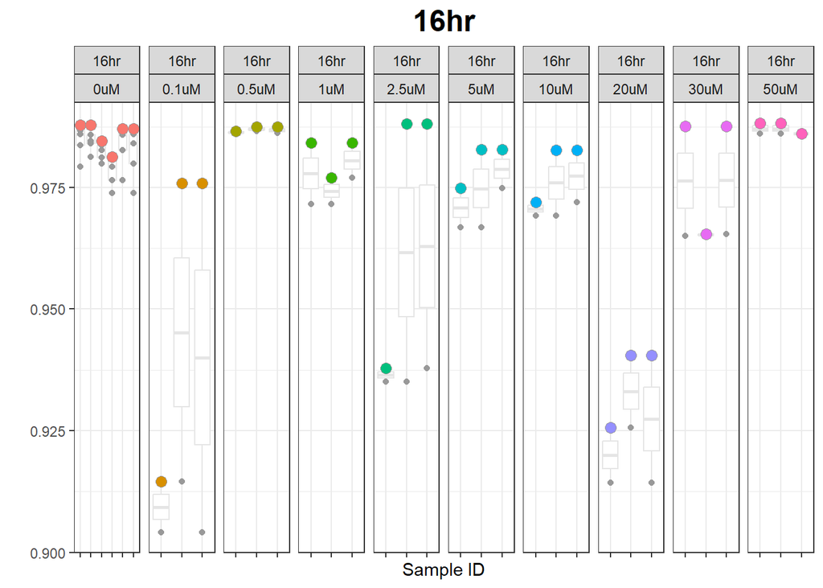

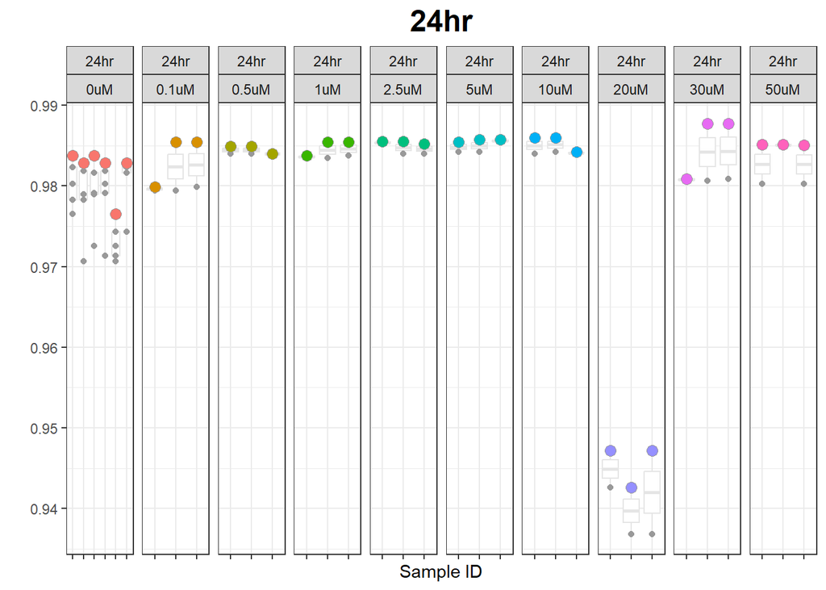

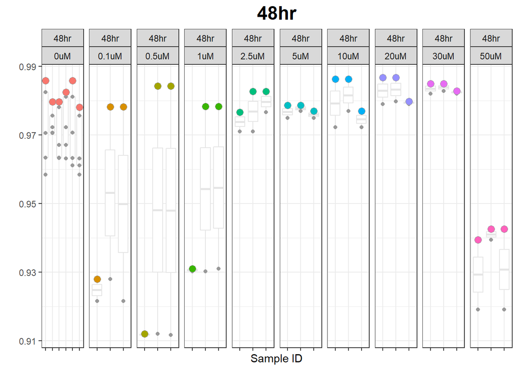

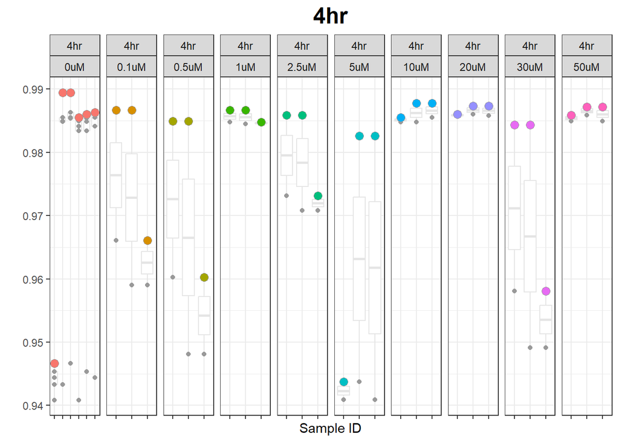

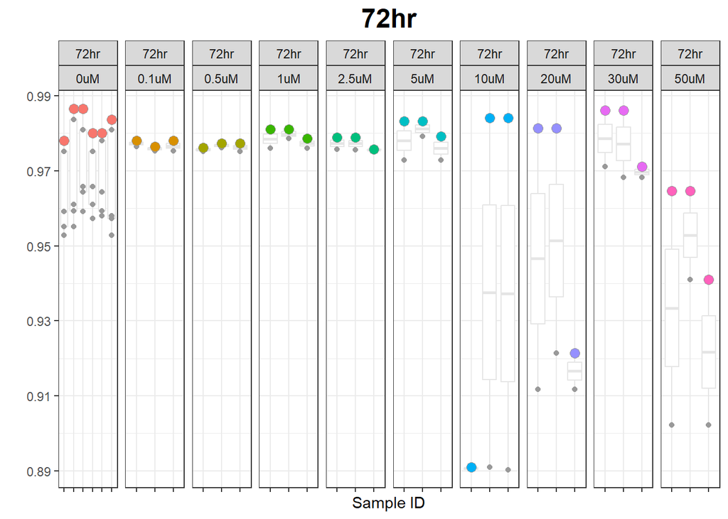

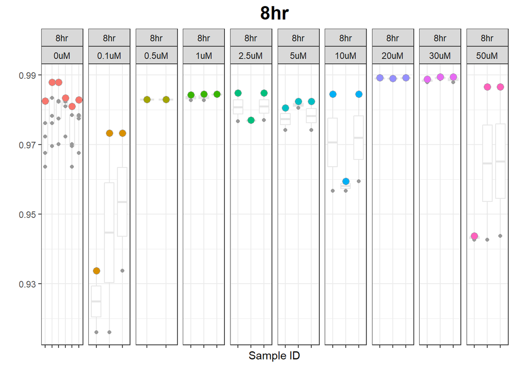

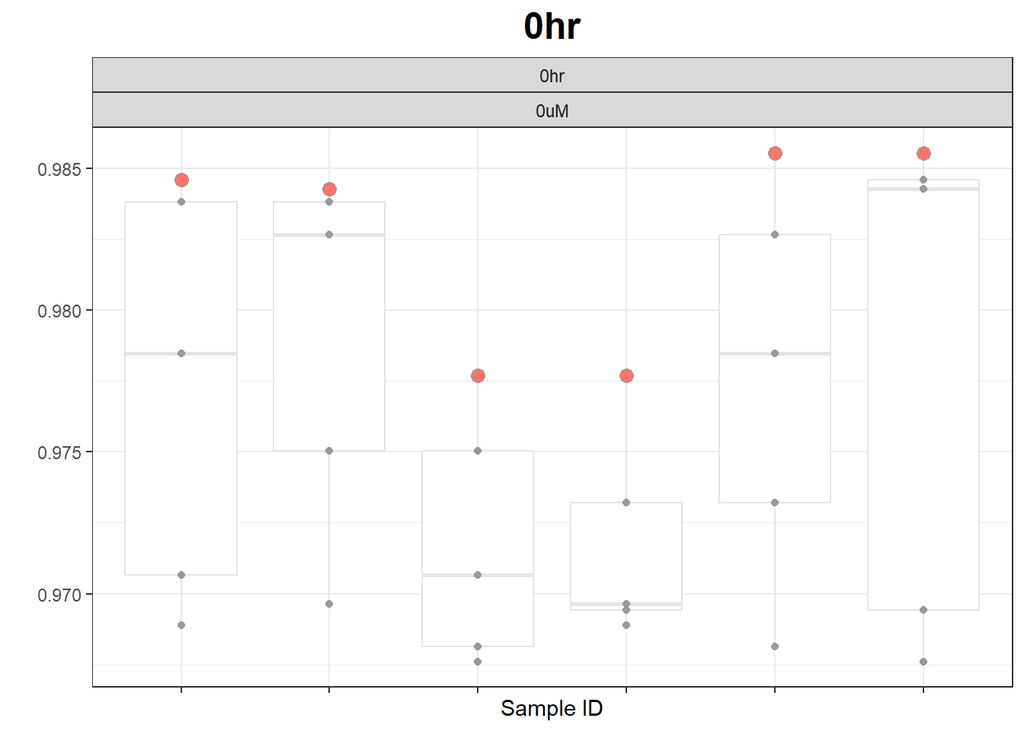

```r
for (i in loop) {
    print(replicateFilterOutput %>%
        filter(time %in% i) %>%
        ggplot(aes(x = reorder(sample_A, factor_conc), y = r2)) + geom_boxplot(color = "grey90") +
        geom_point(color = "grey60") + geom_point(aes(y = max_r2, fill = concentration),
        color = "grey60", shape = 21, size = 3) + ylab("") + xlab("Sample ID") +
        ggtitle(i) + theme_bw() + theme(axis.text.x = element_blank(), legend.position = "none",
        plot.title = element_text(hjust = 0.5, face = "bold", size = 18)) + facet_wrap(~time +
        concentration, scales = "free_x", nrow = 1))
}
```

Look at the distribution of maximum pairwise correlations

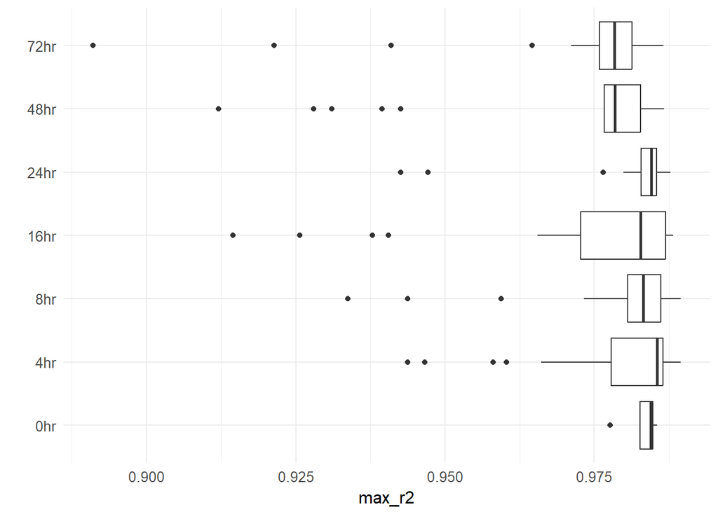

```r
replicateFilterMax <- replicateFilterOutput %>%
    select(time, max_r2) %>%
    distinct()

replicateFilterMax %>%
    group_by(time) %>%
    ungroup() %>%
    ggplot(aes(y = time, x = max_r2)) + geom_boxplot() + ylab("")
```

Some timepoints have less variation in max r2 than others, but we want to capture acceptable variability.

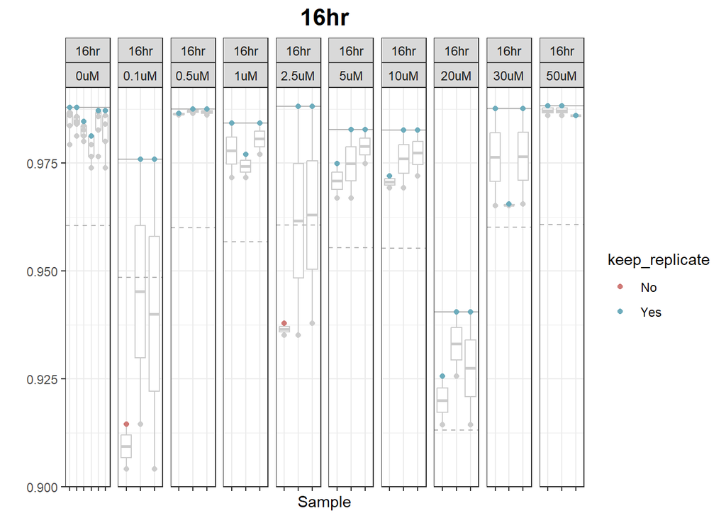

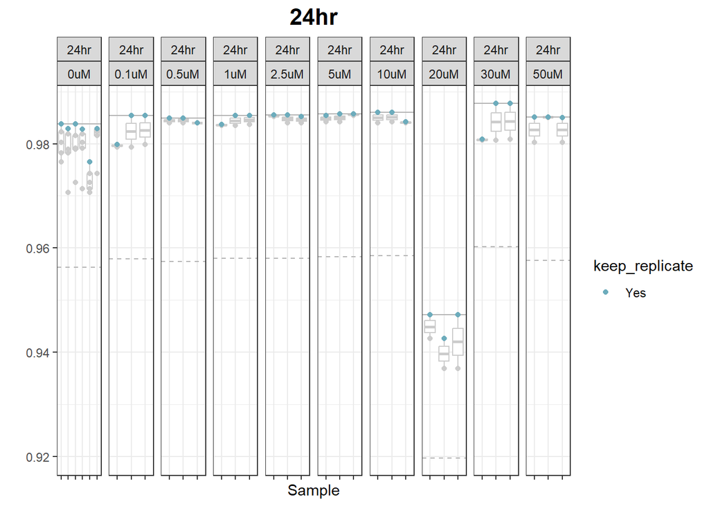

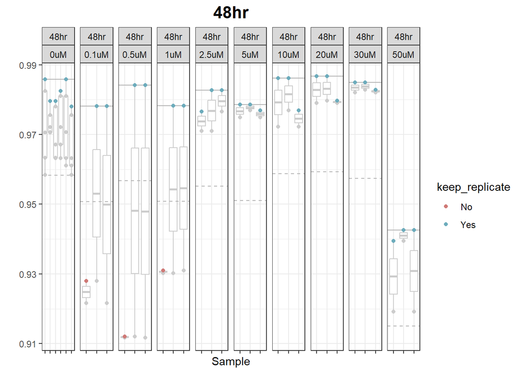

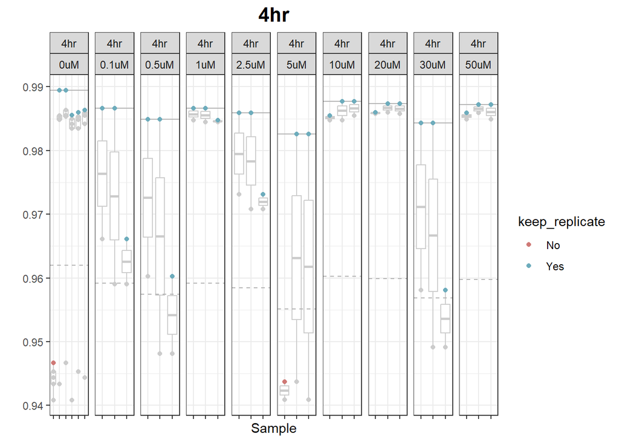

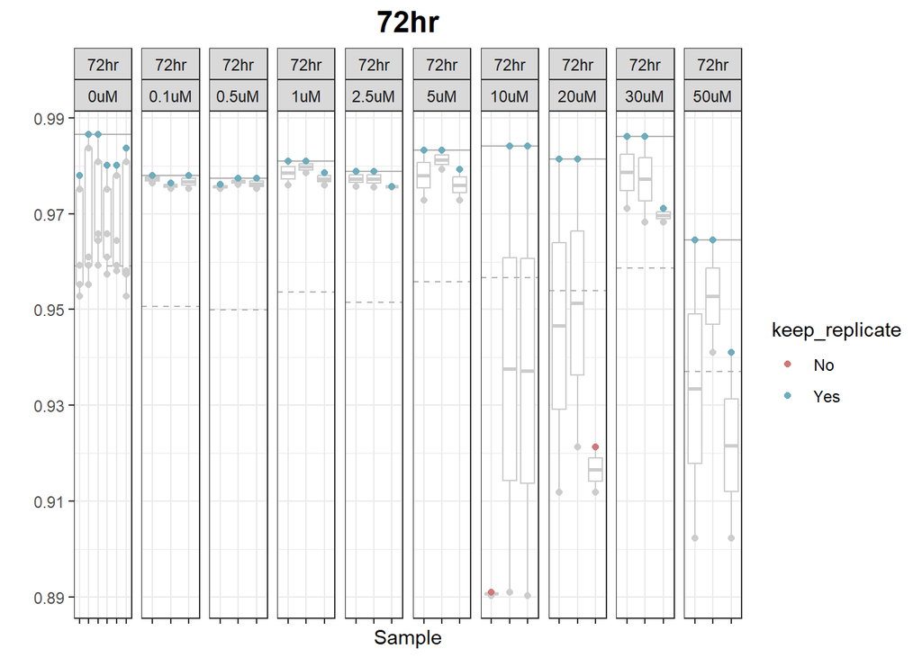

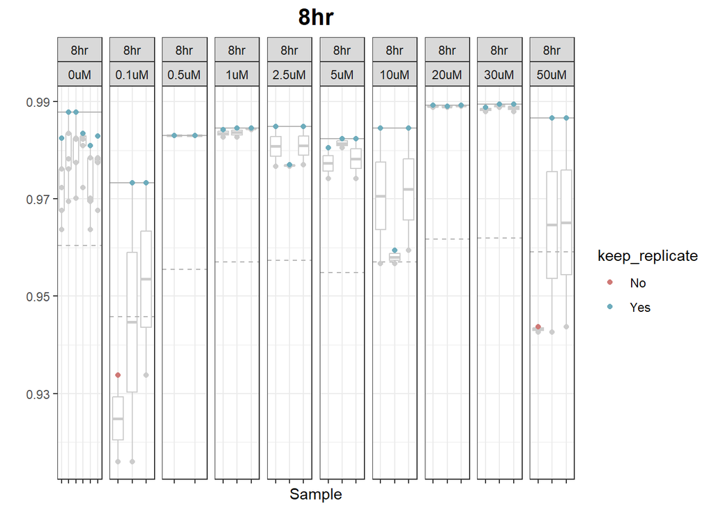

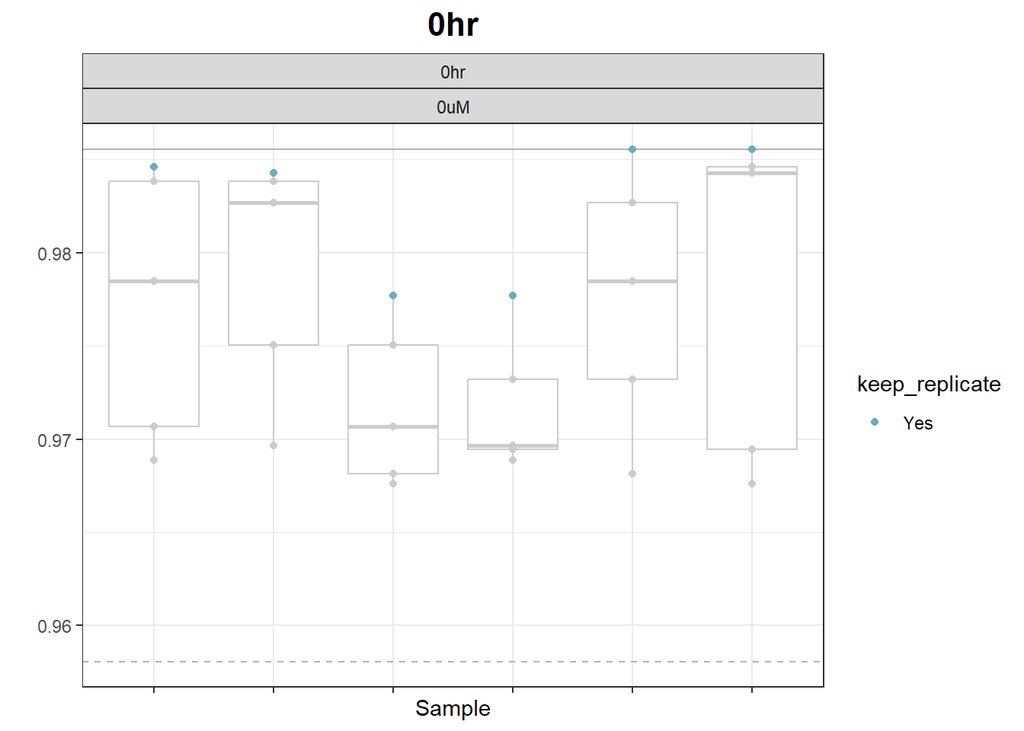

```r
replicateFilterDetect <- replicateFilterOutput %>%
    select(TREATMENT_ID, r2, max_r2) %>%
    distinct() %>%
    mutate(testsystem_IQR = 1.5 * IQR(r2)) %>%
    group_by(TREATMENT_ID) %>%
    mutate(experimental_max = max(max_r2), experimental_threshold = experimental_max -
        testsystem_IQR) %>%
    ungroup() %>%
    select(-r2, -max_r2) %>%
    distinct()

replicateFilterNew <- left_join(replicateFilterOutput, replicateFilterDetect, by = "TREATMENT_ID") %>%
    distinct()

replicateFilterNew <- replicateFilterNew %>%
    mutate(keep_replicate = ifelse(max_r2 < experimental_threshold, "No", "Yes"))

for (i in loop) {
    print(replicateFilterNew %>%
        filter(time == i) %>%
        ggplot(aes(x = reorder(sample_A, -factor_conc))) + geom_boxplot(aes(y = r2),
        color = "grey80") + geom_hline(aes(yintercept = experimental_max), color = "grey70") +
        geom_hline(aes(yintercept = experimental_threshold), color = "grey70", linetype = "dashed") +
        geom_point(aes(y = r2), color = "grey80") + geom_point(aes(y = max_r2, color = keep_replicate)) +
        scale_color_manual(values = c(Yes = "#6DACBC", No = "#CF7976")) + ggtitle(i) +
        xlab("Sample") + ylab("") + theme_bw() + theme(axis.text.x = element_blank(),
        plot.title = element_text(size = 16, face = "bold", hjust = 0.5)) + facet_wrap(~time +
        concentration, scales = "free_x", nrow = 1))
}
```

```r
cat("The replicate filter removes", replicateFilterNew %>%
    filter(keep_replicate == "No") %>%
    pull(sample_A) %>%
    unique() %>%
    length(), "samples.")
```

```
## The replicate filter removes 11 samples.
```

#### 2.2.2.2 Remove samples

From metadata

```r
keepSamples = replicateFilterNew %>%
    filter(keep_replicate == "Yes") %>%
    pull(sample_A) %>%
    unique()

metadata_libSize_repFilter = metadata_libSize %>%
    filter(SAMPLE_ID %in% keepSamples)

cat("The following samples have been removed due to low replicate correlation:\n",
    paste(metadata_libSize %>%
        filter(!SAMPLE_ID %in% keepSamples) %>%
        pull(SAMPLE_ID), collapse = ", "))
```

```
## The following samples have been removed due to low replicate correlation:
##  S_4h_Cis5_Rep1, S_8h_Cis9_Rep1, S_8h_Cis1_Rep1, S_16h_Cis9_Rep1, S_16h_Cis6_Rep1, S_48h_Cis9_Rep1, S_48h_Cis8_Rep1, S_48h_Cis7_Rep1, S_72h_Cis4_Rep1, S_72h_Cis3_Rep3, S_4h_DMEM_Rep1
```

From counts

```r
# raw counts
rawcounts_entrezid_relevanceFilter_sumProbes_libSize_repFilter = rawcounts_entrezid_relevanceFilter_sumProbes_libSize %>%
    select(gene_symbol_entrez_id, metadata_libSize_repFilter$SAMPLE_ID)

# cpm counts
cpmcounts_entrezid_relevancefilter_sumProbes_libSize_repFilter = cpmcounts_entrezid_relevancefilter_sumProbes_libSize %>%
    select(gene_symbol_entrez_id, metadata_libSize_repFilter$SAMPLE_ID)

# log2cpm counts
log2cpmcounts_entrezid_relevanceFilter_sumProbes_libSize_repFilter = log2cpmcounts_entrezid_relevanceFilter_sumProbes_libSize %>%
    select(gene_symbol_entrez_id, metadata_libSize_repFilter$SAMPLE_ID)
```

### 2.2.3 STEP 7: Viable Cells (FrVC)

Flag samples with < 70% viable cells. For this dataset, this information is not available.

### 2.2.4 STEP 8: Fraction uniquely mapped reads (FMR)

Reject samples if percentage mapped is < 70%. For this dataset, this information is not available.

### 2.2.5 STEP 9: Number of genes with >= 5 uniquely mapped reads (Ncov 5)

Flag samples if less than 5000 genes have >= 5 uniquely mapped reads.

```r
# create long df
rawcounts_entrezid_relevanceFilter_sumProbes_libSize_repFilter_long = rawcounts_entrezid_relevanceFilter_sumProbes_libSize_repFilter %>%
    pivot_longer(-gene_symbol_entrez_id, names_to = "SAMPLE_ID", values_to = "counts")

Ncov5_summary = rawcounts_entrezid_relevanceFilter_sumProbes_libSize_repFilter_long %>%
    group_by(SAMPLE_ID) %>%
    summarize(genesAbove5 = sum(counts > 5), lowQuality = genesAbove5 < 5000, .groups = "drop")

head(Ncov5_summary)
```

| SAMPLE_ID | genesAbove5 | lowQuality |
| --- | --- | --- |
| S_0h_DMEM_Rep1 | 9627 | FALSE |
| S_0h_DMEM_Rep2 | 9914 | FALSE |
| S_0h_DMEM_Rep3 | 9826 | FALSE |
| S_0h_DMEM_Rep4 | 10043 | FALSE |
| S_0h_DMEM_Rep5 | 10145 | FALSE |
| S_0h_DMEM_Rep6 | 9896 | FALSE |

```r
table(Ncov5_summary$lowQuality)
```

```
##
## FALSE
##   192
```

```r
Ncov5_flag = Ncov5_summary %>%
    filter(lowQuality == TRUE) %>%
    pull(SAMPLE_ID)
```

### 2.2.6 STEP 10: Number of probes capture top 80% of signal in sample (Nsig 80)

Flag samples if < 1000 genes capture the top 80% of the signal in a sample.

```r
Nsig80_summary = rawcounts_entrezid_relevanceFilter_sumProbes_libSize_repFilter_long %>%
    group_by(SAMPLE_ID) %>%
    arrange(SAMPLE_ID, desc(counts)) %>%
    mutate(cum_sum = cumsum(counts), total = sum(counts), cum_frac = cum_sum/total,
        gene_rank = row_number()) %>%
    filter(cum_frac >= 0.8) %>%
    summarize(Nsig80 = min(gene_rank), lowComplexity = Nsig80 < 1000, .groups = "drop")


head(Nsig80_summary)
```

| SAMPLE_ID | Nsig80 | lowComplexity |
| --- | --- | --- |
| S_0h_DMEM_Rep1 | 1186 | FALSE |
| S_0h_DMEM_Rep2 | 1321 | FALSE |
| S_0h_DMEM_Rep3 | 1323 | FALSE |
| S_0h_DMEM_Rep4 | 1303 | FALSE |
| S_0h_DMEM_Rep5 | 1448 | FALSE |
| S_0h_DMEM_Rep6 | 1285 | FALSE |

```r
table(Nsig80_summary$lowComplexity)
```

```
##
## FALSE  TRUE
##   190     2
```

```r
Nsig80_flag = Nsig80_summary %>%
    filter(lowComplexity == TRUE) %>%
    pull(SAMPLE_ID)
```

### 2.2.7 Add sample flags to metadata

```r
metadata_libSize_repFilter %>%
    mutate(flagged_sampleQC = case_when(SAMPLE_ID %in% Ncov5_flag ~ "Ncov5_flag",
        SAMPLE_ID %in% Nsig80_flag ~ "Nsig80_flag", .default = "passed")) -> metadata_libSize_repFilter
```

### 2.2.8 Check filters in PCA

Check the removed samples in PCA, do we see additional outliers, are these removed if we increase the libsize filter/adjust the replicate correlation?

Before the low quality samples have been removed

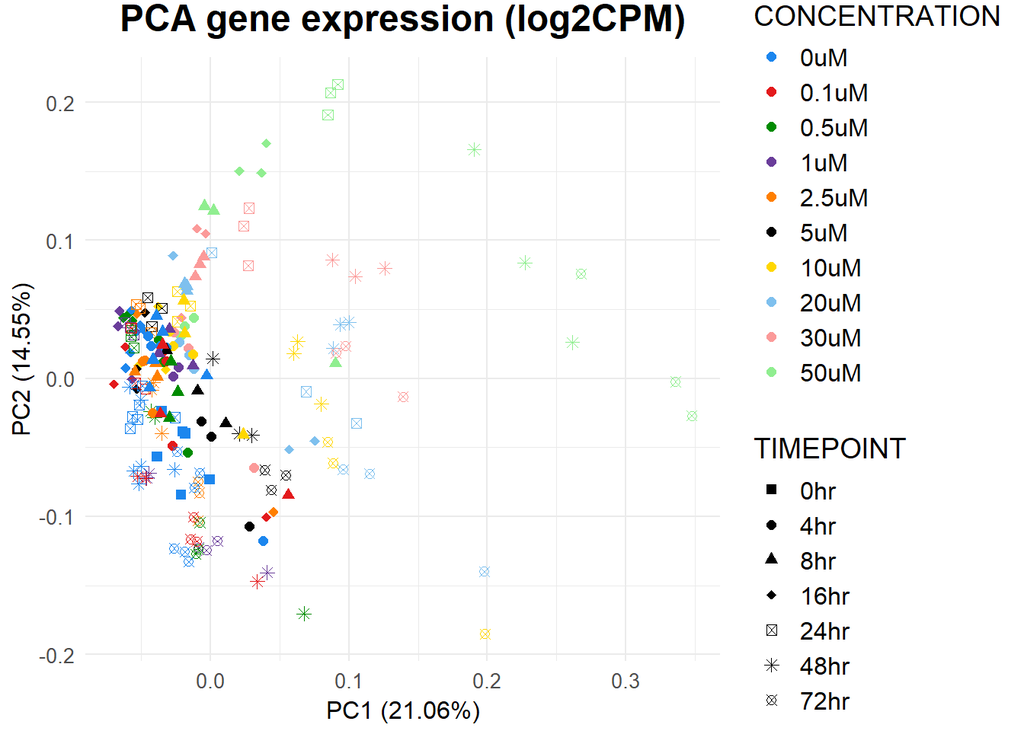

```r
pcaData_beforeSampFilter = log2cpmcounts_entrezid_relevanceFilter_sumProbes %>% column_to_rownames("gene_symbol_entrez_id") %>% t() %>% as.data.frame() %>% rownames_to_column("SAMPLE_ID") %>% left_join(metadata, by = "SAMPLE_ID") %>%
  mutate(removed_sampleQC = if_else(SAMPLE_ID %in% metadata_libSize_repFilter$SAMPLE_ID, true = "passed", false = "notPassed"),
         Ncov5_flag = if_else(SAMPLE_ID %in% Ncov5_flag, true = "flag", false = "passed"),
         Nsig80_flag = if_else(SAMPLE_ID %in% Nsig80_flag, true = "flag", false = "passed"))

pcaOutput_beforeSampFilter = prcomp(pcaData_beforeSampFilter %>% column_to_rownames("SAMPLE_ID") %>% select(log2cpmcounts_entrezid_relevanceFilter_sumProbes$gene_symbol_entrez_id))

autoplot(
  pcaOutput_beforeSampFilter,
  data = pcaData_beforeSampFilter,
  color = "CONCENTRATION",
  shape = "TIMEPOINT",
  size = 2
) + # change to 3
  labs(title = "PCA gene expression (log2CPM)") +
  scale_shape_manual(values = c(15, 16, 17, 18, 7, 8, 13)) +
  scale_color_manual(values = color25)
```

Color removed samples

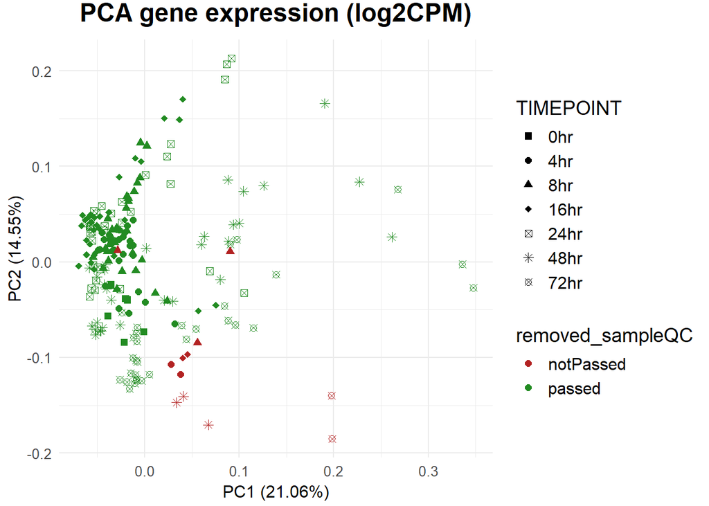

```r
autoplot(
  pcaOutput_beforeSampFilter,
  data = pcaData_beforeSampFilter,
  color = "removed_sampleQC",
  shape = "TIMEPOINT",
  size = 2
) + # change to 3
  labs(title = "PCA gene expression (log2CPM)") +
  scale_shape_manual(values = c(15, 16, 17, 18, 7, 8, 13)) +
  scale_color_manual(values = c("firebrick", "forestgreen"),
                     breaks = c("notPassed", "passed"))
```

Check flagged samples

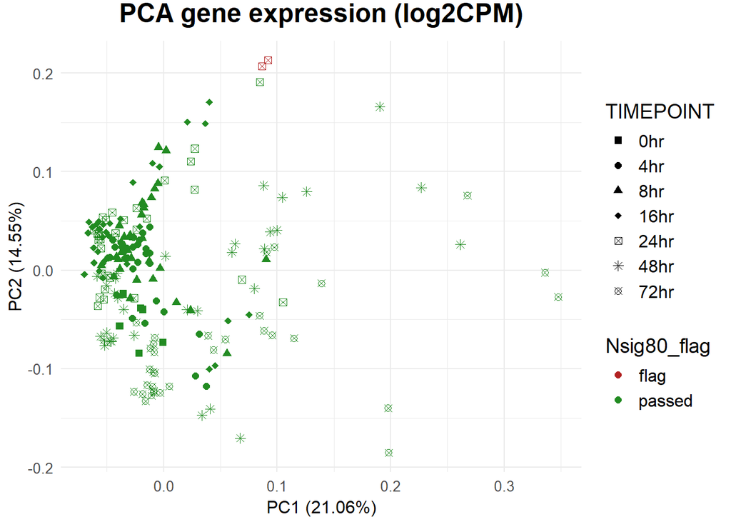

```r
autoplot(
  pcaOutput_beforeSampFilter,
  data = pcaData_beforeSampFilter,
  color = "Nsig80_flag",
  shape = "TIMEPOINT",
  size = 2
) + # change to 3
  labs(title = "PCA gene expression (log2CPM)") +
  scale_shape_manual(values = c(15, 16, 17, 18, 7, 8, 13)) +
  scale_color_manual(values = c("firebrick", "forestgreen"),
                     breaks = c("flag", "passed"))
```

After the low quality samples have been removed

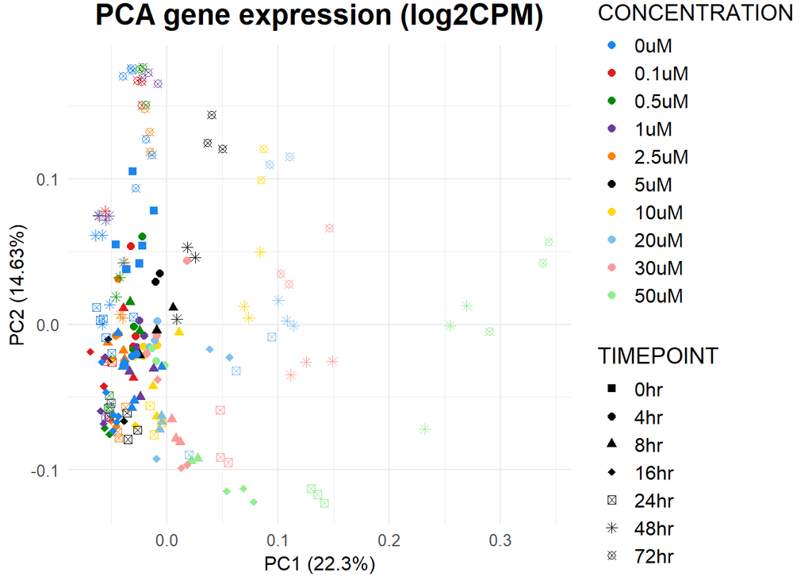

```r
pcaData_afterSampleFilter = log2cpmcounts_entrezid_relevanceFilter_sumProbes_libSize_repFilter %>% column_to_rownames("gene_symbol_entrez_id") %>% t() %>% as.data.frame() %>% rownames_to_column("SAMPLE_ID") %>% left_join(metadata_libSize_repFilter, by = "SAMPLE_ID")

pcaOutput_afterSampleFilter = prcomp(pcaData_afterSampleFilter %>% column_to_rownames("SAMPLE_ID") %>% select(log2cpmcounts_entrezid_relevanceFilter_sumProbes_libSize_repFilter$gene_symbol_entrez_id))

autoplot(
  pcaOutput_afterSampleFilter,
  data = pcaData_afterSampleFilter,
  color = "CONCENTRATION",
  shape = "TIMEPOINT",
  size = 2
) + # change to 3
  labs(title = "PCA gene expression (log2CPM)") +
  scale_shape_manual(values = c(15, 16, 17, 18, 7, 8, 13)) +
  scale_color_manual(values = color25)
```

Color flagged samples after filter

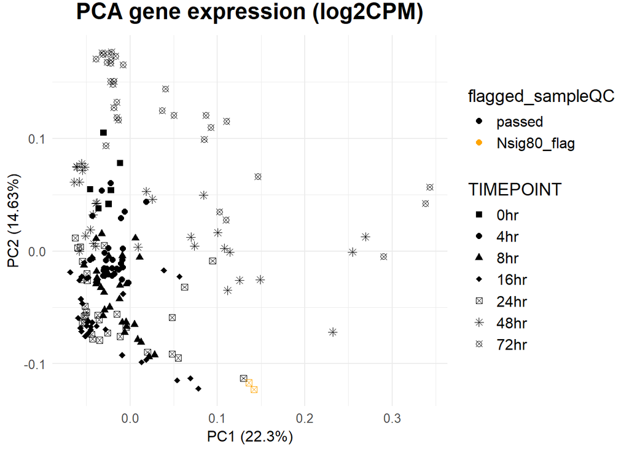

```r
autoplot(
  pcaOutput_afterSampleFilter,
  data = pcaData_afterSampleFilter,
  color = "flagged_sampleQC",
  shape = "TIMEPOINT",
  size = 2
) + # change to 3
  labs(title = "PCA gene expression (log2CPM)") +
  scale_shape_manual(values = c(15, 16, 17, 18, 7, 8, 13)) +
  scale_color_manual(values = c("black", "orange", "purple"),
                     breaks = c("passed", "Nsig80_flag", "Ncov5_flag"))
```

The flagged samples are nicely clustered with their replicate, so for now I decided to keep them in.

### 2.2.9 Save data

```r
save(
  # metadata
  metadata_libSize_repFilter,

  # raw counts
  rawcounts_entrezid_relevanceFilter_sumProbes_libSize_repFilter,

  # cpm counts
  cpmcounts_entrezid_relevancefilter_sumProbes_libSize_repFilter,

  # log2cpm counts
  log2cpmcounts_entrezid_relevanceFilter_sumProbes_libSize_repFilter,

  file = file.path(outputDir, "updatedVersion", paste0(studyNR, "_dataAfterSampleQC.RData"))

)
```